# Zombies!

# Homework 3

[figure not shown]

An enhanced “affamé” from Daryl Dixon (The Walking Dead Spinoff)

## Preliminary

```r
#install.packages("rmdformats", repos = "http://cran.us.r-project.org")
library(tidyverse)
```

```r
library(rmdformats)
library(cowplot)
library(gridGraphics)
# Read zombies.csv and store data in dataframe df
df <- read.csv("https://raw.githubusercontent.com/fuzzyatelin/fuzzyatelin.github.io/refs/heads/master/AN588_Spring25/zombies.csv")

df <- df %>%
  mutate(
    id = as.numeric(id),
    first_name = as.factor(first_name),
    last_name = as.factor(last_name),
    gender = as.factor(gender),
    height = as.numeric(height),
    weight = as.numeric(weight),
    zombies_killed = as.numeric(zombies_killed),
    years_of_education = as.numeric(years_of_education),
    major = as.factor(major),
    age = as.numeric(age)
  ) %>%
  rename(education = years_of_education)
```

## Question 1

Calculate the *population* mean and standard deviation for each quantitative random variable (height, weight, age, number of zombies killed, and years of education).

```r
# defining functions for population variance (pop_var) and
# population standard deviation (pop_sd)
pop_var <- function(x){
  sum((x - mean(x))^2)/(length(x))  # sum of squares over population size
}
pop_sd <- function(x){
  sqrt(pop_var(x))  # sqrt of variance = standard deviation
}

h_mean <- mean(df$height) # mean height
h_sd <- pop_sd(df$height) # sd of height
w_mean <- mean(df$weight) # mean weight
w_sd <- pop_sd(df$weight)
age_mean <- mean(df$age) # mean age
age_sd <- pop_sd(df$age)
kdr_mean <- mean(df$zombies_killed) # mean number of zombies killed
kdr_sd <- pop_sd(df$zombies_killed)
edu_mean <- mean(df$education) # mean number of years of education
edu_sd <- pop_sd(df$education)

# creating matrix of stats for easy access
names <- c("height", "weight", "age", "zombies_killed", "education")
stat_array <- c(h_mean, h_sd, w_mean, w_sd, age_mean, age_sd, kdr_mean, kdr_sd, edu_mean, edu_sd)

pop_stats <- matrix(stat_array, nrow=5, ncol=2, byrow=TRUE)
rownames(pop_stats) <- names
colnames(pop_stats) <- c("Mean", "SD")
pop_stats
```

```
##                     Mean        SD
## height          67.63010  4.307970
## weight         143.90748 18.391857
## age             20.04696  2.963583
## zombies_killed   2.99200  1.747551
## education        2.99600  1.675704
```

## Question 2

Use {ggplot} to make boxplots of each of these variables by gender.

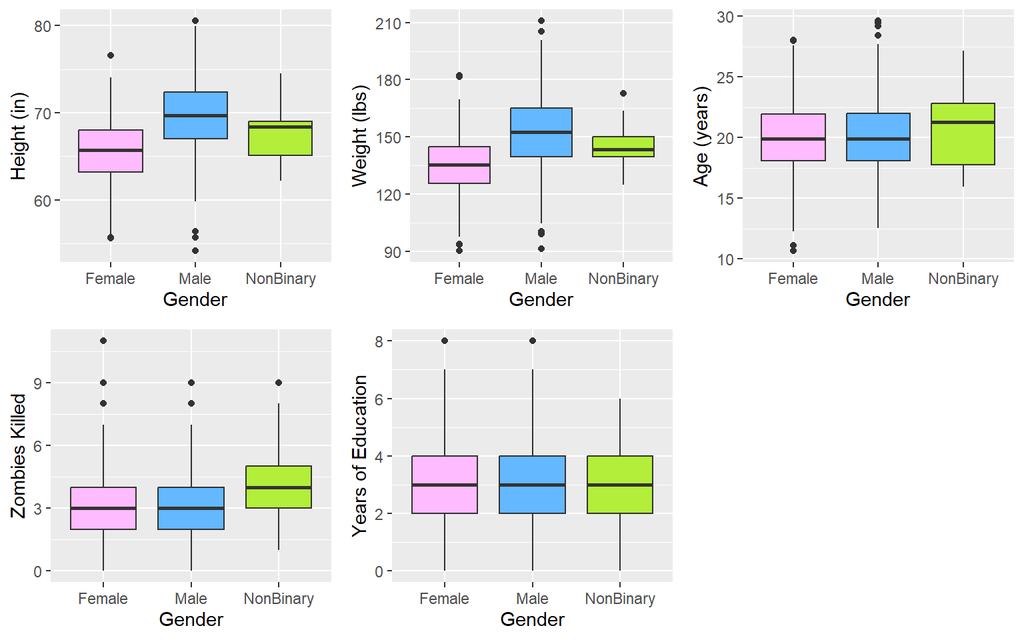

```r
colors = c("plum1","steelblue1", "olivedrab2")

# creating plots to be placed in array
# mean height
p1 <- ggplot(data=df, aes(x = gender, y = height, fill = gender))
p1 <- p1 + geom_boxplot(show.legend = FALSE)
p1 <- p1 + ylab("Height (in)")
p1 <- p1 + xlab("Gender")
p1 <- p1 + scale_fill_manual(values = colors)

# mean weight
p2 <- ggplot(data=df, aes(x = gender, y = weight, fill = gender))
p2 <- p2 + geom_boxplot(show.legend = FALSE)
p2 <- p2 + ylab("Weight (lbs)")
p2 <- p2 + xlab("Gender")
p2 <- p2 + scale_fill_manual(values = colors)

# mean age
p3 <- ggplot(data=df, aes(x = gender, y = age, fill = gender))
p3 <- p3 + geom_boxplot(show.legend = FALSE)
p3 <- p3 + ylab("Age (years)")
p3 <- p3 + xlab("Gender")
p3 <- p3 + scale_fill_manual(values = colors)

# mean zombies killed
p4 <- ggplot(data=df, aes(x = gender, y = zombies_killed, fill = gender))
p4 <- p4 + geom_boxplot(show.legend = FALSE)
p4 <- p4 + ylab("Zombies Killed")
p4 <- p4 + xlab("Gender")
p4 <- p4 + scale_fill_manual(values = colors)

# mean years of education
p5 <- ggplot(data=df, aes(x = gender, y = education, fill = gender))
p5 <- p5 + geom_boxplot(show.legend = FALSE)
p5 <- p5 + ylab("Years of Education")
p5 <- p5 + xlab("Gender")
p5 <- p5 + scale_fill_manual(values = colors)

# Plot grid
pgrid1 <- plot_grid(p1, p2, p3, p4, p5, nrow = 2, ncol = 3)
pgrid1
```

## Question 3

### 3.1

Use {ggplot} to make scatterplots of height and weight in relation to age.

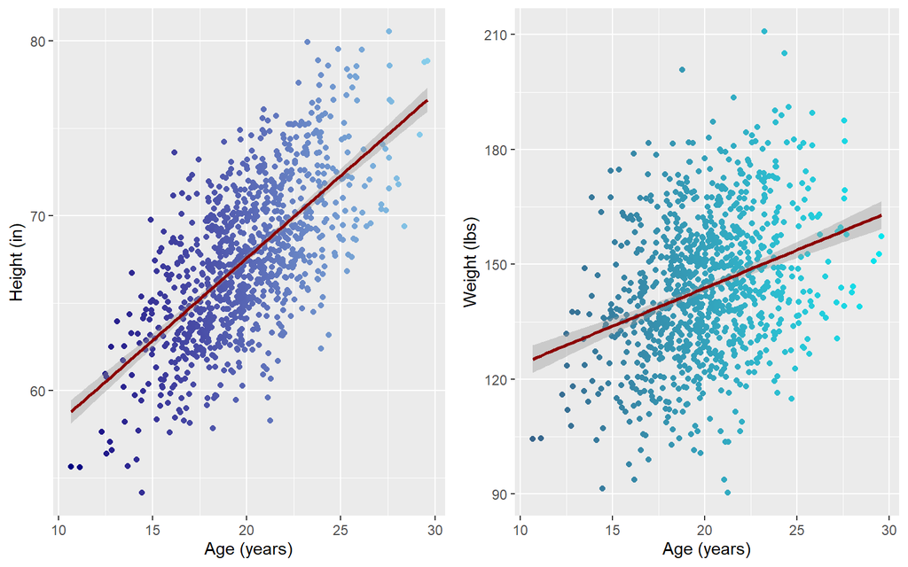

```r
# creating plots to go into the grid
p6 <- ggplot(df, aes(x = age, y = height, color = age))
p6 <- p6 + geom_point()  # Scatter plot
p6 <- p6 + geom_smooth(method = "lm", color = "darkred")  # Line of best fit (linear regression)
p6 <- p6 + ylab("Height (in)")
p6 <- p6 + xlab("Age (years)")
p6 <- p6 + scale_color_gradient(low = "navy", high = "skyblue") + theme(legend.position = "none")

p7 <- ggplot(df, aes(x = age, y = weight, color = age))
p7 <- p7 + geom_point()  # Scatter plot
p7 <- p7 + geom_smooth(method = "lm", color = "darkred")  # Line of best fit (linear regression)
p7 <- p7 + ylab("Weight (lbs)")
p7 <- p7 + xlab("Age (years)")
p7 <- p7 + scale_color_gradient(low="steelblue4", high="turquoise2") + theme(legend.position = "none")

# creating plot grid
pgrid2 <- plot_grid(p6, p7)
pgrid2
```

### 3.2

Do these variables seem to be related? In what way?

> Yes, both height and weight appear to be positively correlated with age.

## Question 4

### 4.1

Using histograms and Q-Q plots, check whether the quantitative variables seem to be drawn from a normal distribution.

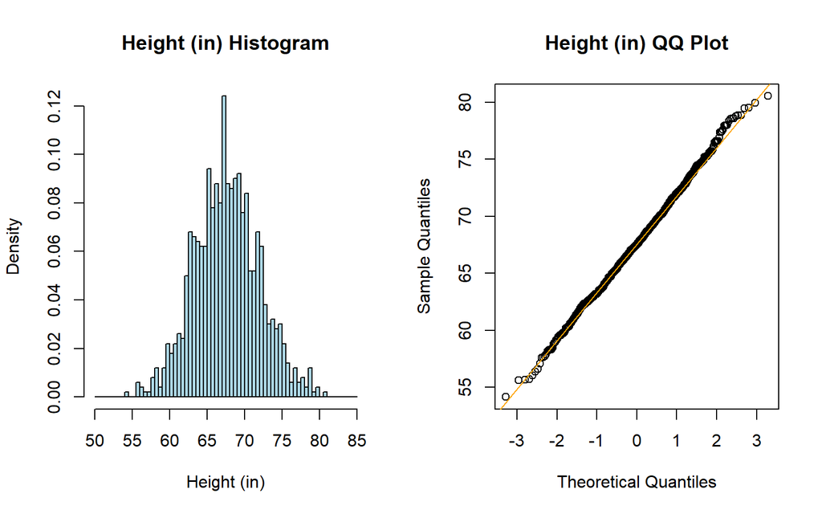

```r
# defines function to create plot grid for each variable
# takes as parameters data (variable), breaks (seq of breaks),
#   and xlab (name of var for labels)
plot_hist_qq <- function(data, breaks, xlab) {

  # creates histogram for each var and stores in temporary object hist_plot
  hist_plot <- function(){
    hist(data, breaks = breaks, probability = TRUE, xlab = xlab, col = "lightblue", main = paste(xlab, "Histogram"))
  }

  # creates qq plot with a line for each var and stores in temporary object qq_plot
  qq_plot <- function(){
    qqnorm(data, main = paste(xlab, "QQ Plot"))
    qqline(data, col = "orange")
  }

  # uses cowplot to combine the two temp plots for each var in side by side (1x2)
  plot_grid(hist_plot, qq_plot, ncol = 2)
}

pgrid3 <- plot_hist_qq(df$height, seq(50, 85, 0.5), "Height (in)")
pgrid4 <- plot_hist_qq(df$weight, seq(90, 215, 1), "Weight (lbs)")
pgrid5 <- plot_hist_qq(df$age, seq(10, 30, 0.5), "Age")
pgrid6 <- plot_hist_qq(df$zombies_killed, seq(0, 12, 1), "Zombies Killed")
pgrid7 <- plot_hist_qq(df$education, seq(0, 8, 1), "Years of Education")

pgrid3
```

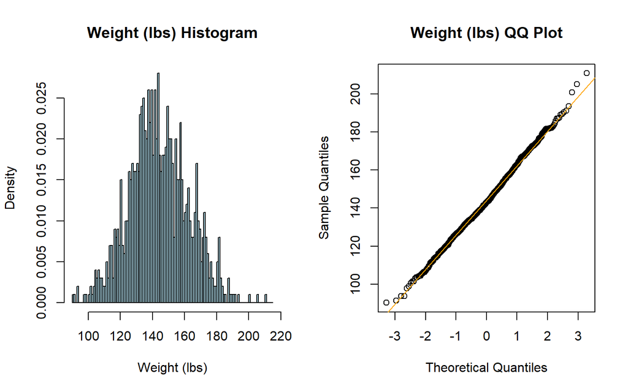

```r
pgrid4
```

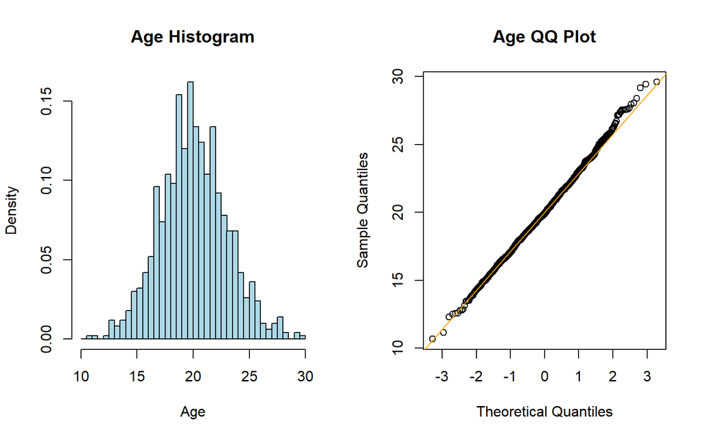

```r
pgrid5
```

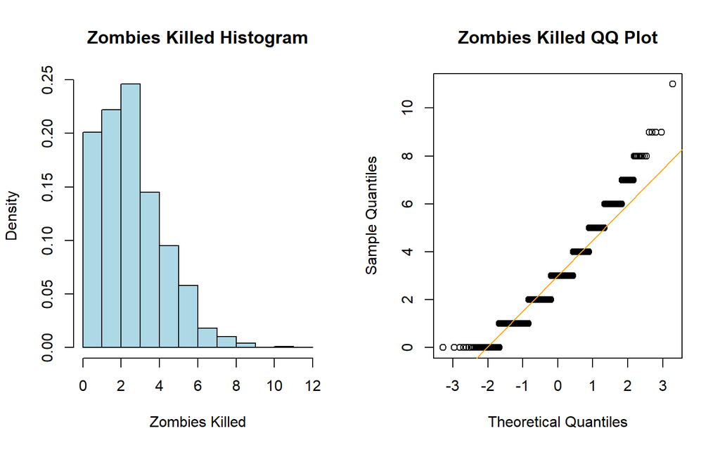

```r
pgrid6
```

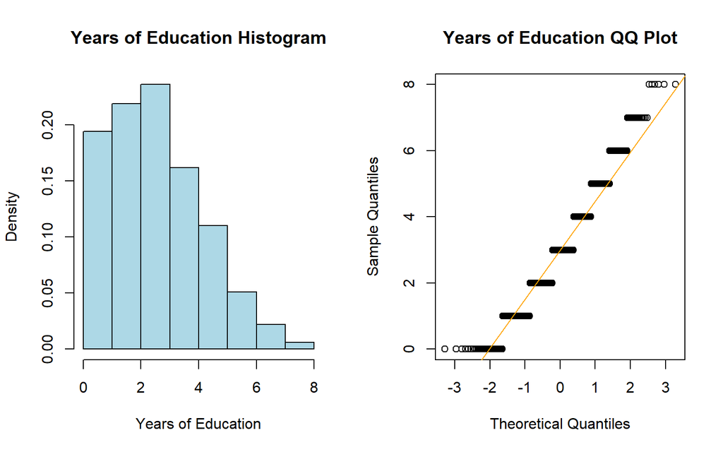

```r
pgrid7
```

### 4.2

Which seem to be and which do not (hint: not all are drawn from the normal distribution)?

> It seems like Zombies Killed and Years of Education are the only statistics that aren’t drawn from the normal distribution.

### 4.3

For those that are not normal, can you determine from which common distribution they are drawn?

> Both are count data, so I think they draw from a Poisson distribution.

## Question 5

### 5.1

Now use the `sample()` function to sample ONE subset of 30 zombie survivors (without replacement) from this population and calculate the mean and sample standard deviation for each variable.

```r
# create a sample, s, of size 30 without replacement
n = 30
s <- sample_n(df, size = n, replace = FALSE)

# calculate the mean and standard deviation (sd) for each statistic of the sample
s_h_mean <- mean(s$height) # mean height of the sample
s_h_sd <- sd(s$height) # sd of the height of the sample
s_w_mean <- mean(s$weight) # mean weight of the sample
s_w_sd <- sd(s$weight) # sd of the weight of the sample
s_a_mean <- mean(s$age) # mean age of the sample
s_a_sd <- sd(s$age) # sd of the age of the sample
s_k_mean <- mean(s$zombies_killed) # mean number of zombies killed of the sample
s_k_sd <- sd(s$zombies_killed) # sd of the num of zombies killed of the sample
s_e_mean <- mean(s$education) # mean years of education of the sample
s_e_sd <- sd(s$education) # sd of the years of education of the sample

# create an array of the sample stats for presentation
stat_array <- c(s_h_mean, s_h_sd, s_w_mean, s_w_sd, s_a_mean, s_a_sd, s_k_mean, s_k_sd, s_e_mean, s_e_sd)
samp_stats <- matrix(stat_array, ncol=2, byrow=TRUE)
rownames(samp_stats) <- names
colnames(samp_stats) <- c("Mean", "SD")
samp_stats
```

```
##                      Mean        SD
## height          66.986630  4.423513
## weight         142.559798 18.893252
## age             19.053106  3.227921
## zombies_killed   2.933333  1.507071
## education        3.133333  1.870521
```

### 5.2

Also estimate the standard error for each variable, and construct the 95% confidence interval for each mean.

Note that for the variables that are not drawn from the normal distribution, you may need to base your estimate of the CIs on slightly different code than for the normal…

```r
# store the estimated standard error for each variable;
# h = height, w = weight, a = age, k = zombies_killed, e = years of education
# s refers to the sample created in 5.1
h_std_err <- s_h_sd/sqrt(n)
w_std_err <- s_w_sd/sqrt(n)
a_std_err <- s_a_sd/sqrt(n)
k_std_err <- s_k_sd/sqrt(n)
e_std_err <- s_e_sd/sqrt(n)

# create lists of the standard errors, means, and variable names
sems <- c(h_std_err, w_std_err, a_std_err, k_std_err, e_std_err)
means <- c(s_h_mean, s_w_mean, s_a_mean, s_k_mean, s_e_mean)
names <- c("height", "weight", "age", "zombies_killed", "education")

# create holders for lower, upper, and CI to fill with loop
lowers <- NULL
uppers <- NULL
cis <- vector("list", length(sems))

# for each variable, calculate and store in the "cis" list
# the lower, upper, and CI where alpha = 0.05
for(i in 1:length(sems)){
  lowers[i] <- means[i] - qnorm(1 - 0.05/2) * sems[i] # (1-alpha)/2 in the upper and lower tails of the   distribution
  uppers[i] <- means[i] + qnorm(1 - 0.05/2) * sems[i]
  cis[[i]] <- c(lowers[i], uppers[i])
}

# create a matrix of the standard errors for presentation
samp_SEMs <- matrix(sems, nrow = 5, ncol = 1, byrow = TRUE)
rownames(samp_SEMs) <- names
colnames(samp_SEMs) <- "SEM"

# create a matrix of the CIs for presentation
samp_CIs <- matrix(unlist(cis), nrow = 5, ncol = 2, byrow = TRUE)
rownames(samp_CIs) <- names
colnames(samp_CIs) <- c("lower", "upper")

samp_SEMs
```

```
##                      SEM
## height         0.8076194
## weight         3.4494202
## age            0.5893350
## zombies_killed 0.2751523
## education      0.3415089
```

```r
samp_CIs
```

```
##                     lower      upper
## height          65.403725  68.569534
## weight         135.799059 149.320538
## age             17.898031  20.208182
## zombies_killed   2.394045   3.472622
## education        2.463988   3.802679
```

## Question 6

### 6.1

Now draw 99 more random samples of 30 zombie apocalypse survivors, and calculate the mean for each variable for each of these samples.

```r
samp_means <- vector("list", 99)
for (i in 1:99) {
    temp <- sample_n(df, size = n, replace = FALSE)
    samp_means[[i]] <- c(mean(temp$height), mean(temp$weight), mean(temp$age), mean(temp$zombies_killed), mean(temp$education))
}
```

### 6.2

Together with the first sample you drew, you now have a set of 100 means for each variable (each based on 30 observations), which constitutes a *sampling* distribution for each variable. What are the means and standard deviations of this distribution of means for each variable?

```r
# convert means (array of means from first sample) into a list
# concatenate the means list with the samp_means list (the list of means for the 99 samples)
means <- list(means)
samp_means <- c(samp_means, means)

# Now we have a list of 100 vectors of means

# initialize an empty vector for each variable to store
# the values of the corresponding variables for each sample
samp_heights <- NULL
samp_weights <- NULL
samp_ages <- NULL
samp_kills <- NULL
samp_edus <- NULL

# for all 100 samples, store the appropriate variable
# in the corresponding vector
for(i in 1:100){
  samp_heights[i] = samp_means[[i]][1]
  samp_weights[i] = samp_means[[i]][2]
  samp_ages[i] = samp_means[[i]][3]
  samp_kills[i] = samp_means[[i]][4]
  samp_edus[i] = samp_means[[i]][5]
}

# store the mean and sd of the means for each variable of each sample
s_h_mean <- mean(samp_heights)
s_h_sd <- sd(samp_heights)
s_w_mean <- mean(samp_weights)
s_w_sd <- sd(samp_weights)
s_a_mean <- mean(samp_ages)
s_a_sd <- sd(samp_ages)
s_k_mean <- mean(samp_kills)
s_k_sd <- sd(samp_kills)
s_e_mean <- mean(samp_edus)
s_e_sd <- sd(samp_edus)

# create a vector of the means and sds
stat_array <- c(s_h_mean, s_h_sd, s_w_mean, s_w_sd, s_a_mean, s_a_sd, s_k_mean, s_k_sd, s_e_mean, s_e_sd)

# use the stat_array vector to create a matrix of means and sds for presentation
samp_stats <- matrix(stat_array, nrow=5, ncol=2, byrow=TRUE)
rownames(samp_stats) <- names
colnames(samp_stats) <- c("Mean", "SD")
samp_stats
```

```
##                      Mean        SD
## height          67.502347 0.7747922
## weight         143.363455 3.4777532
## age             20.052824 0.5020027
## zombies_killed   2.980667 0.3086184
## education        2.986000 0.2864379
```

### 6.3

How do the standard deviations of means compare to the standard errors estimated in
$$5$$
?

```r
samp_SEMs
```

```
##                      SEM
## height         0.8076194
## weight         3.4494202
## age            0.5893350
## zombies_killed 0.2751523
## education      0.3415089
```

```r
samp_stats
```

```
##                      Mean        SD
## height          67.502347 0.7747922
## weight         143.363455 3.4777532
## age             20.052824 0.5020027
## zombies_killed   2.980667 0.3086184
## education        2.986000 0.2864379
```

### 6.4

What do these sampling distributions look like (a graph might help here)? Are they normally distributed?

```r
temp <- matrix(unlist(samp_means), ncol = 5, nrow = 100, byrow = TRUE)
colnames(temp) <- names
samp_df <- data.frame(temp)
```

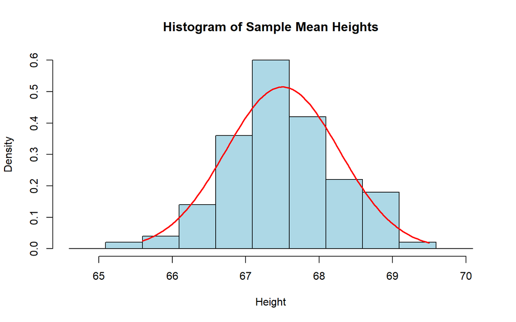

```r
hist(samp_df$height, breaks = seq(from=min(samp_df$height) - 1, to=max(samp_df$height) + 1, by = 0.5), xlab = "Height", main = "Histogram of Sample Mean Heights", probability = TRUE, col="lightblue")
x_vals <- seq(min(samp_df$height), max(samp_df$height), length = 100)
y_vals <- dnorm(x_vals, mean = mean(samp_df$height), sd = sd(samp_df$height))
lines(x_vals, y_vals, col = "red", lwd = 2)
```

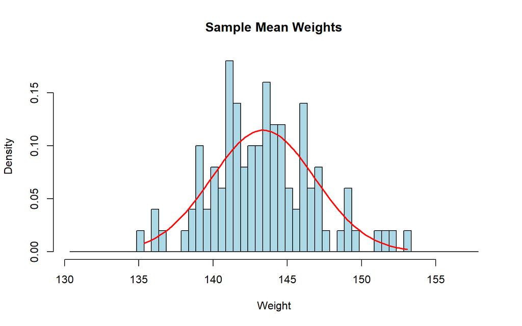

```r
hist(samp_df$weight, breaks = seq(from=min(samp_df$weight) - 5, to=max(samp_df$weight) + 5, by = 0.5), xlab = "Weight", main = "Sample Mean Weights", probability = TRUE, col="lightblue")
x_vals <- seq(min(samp_df$weight), max(samp_df$weight), length = 100)
y_vals <- dnorm(x_vals, mean = mean(samp_df$weight), sd = sd(samp_df$weight))
lines(x_vals, y_vals, col = "red", lwd = 2)
```

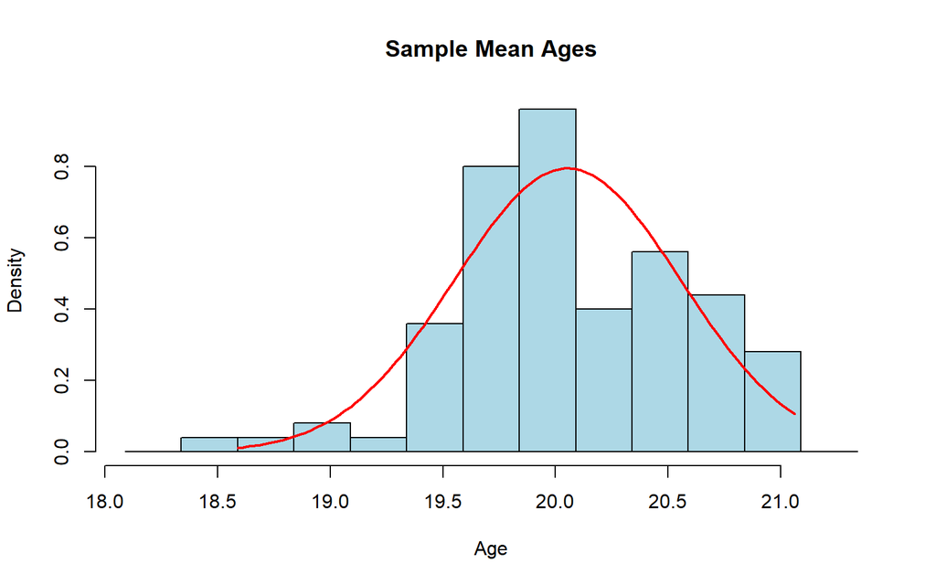

```r
hist(samp_df$age, breaks = seq(from=min(samp_df$age) - 0.5, to=max(samp_df$age) + 0.5, by = 0.25), xlab = "Age", main = "Sample Mean Ages", probability = TRUE, col="lightblue")
x_vals <- seq(min(samp_df$age), max(samp_df$age), length = 100)
y_vals <- dnorm(x_vals, mean = mean(samp_df$age), sd = sd(samp_df$age))
lines(x_vals, y_vals, col = "red", lwd = 2)
```

> Weight appears less normally distributed than I thought, but height and age are pretty normal

What about for those variables that you concluded were *not* originally drawn from a normal distribution?

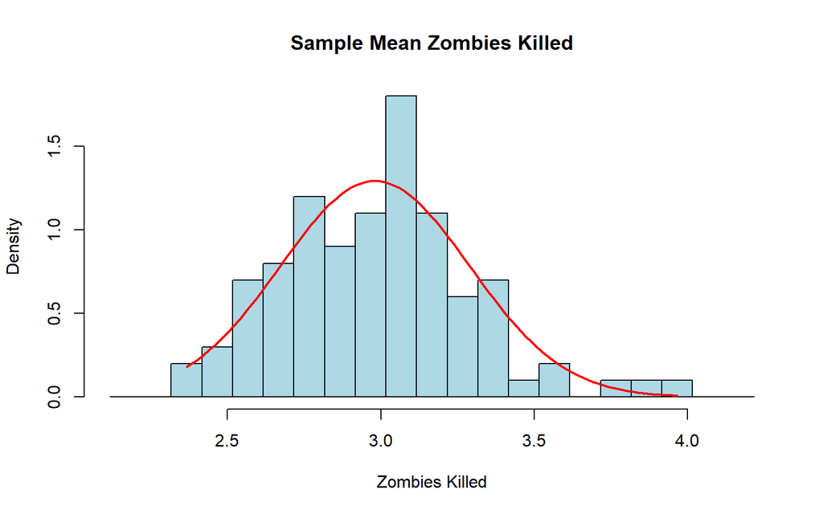

```r
hist(samp_df$zombies_killed, breaks = seq(from=min(samp_df$zombies_killed) - 0.25, to=max(samp_df$zombies_killed) + 0.25, by = 0.1), xlab = "Zombies Killed", main = "Sample Mean Zombies Killed", probability = TRUE, col="lightblue")
x_vals <- seq(min(samp_df$zombies_killed), max(samp_df$zombies_killed), length = 100)
y_vals <- dnorm(x_vals, mean = mean(samp_df$zombies_killed), sd = sd(samp_df$zombies_killed))
lines(x_vals, y_vals, col = "red", lwd = 2)
```

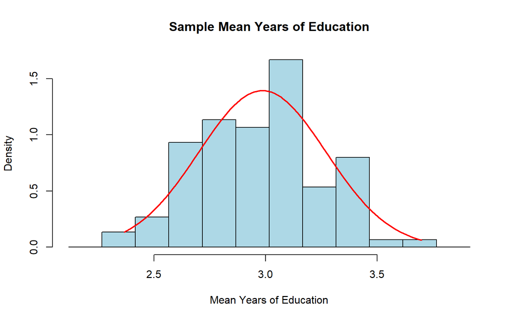

```r
hist(samp_df$education, breaks = seq(from=min(samp_df$education - .25), to=max(samp_df$education + .25), by = 0.15), xlab = "Mean Years of Education", main = "Sample Mean Years of Education", probability = TRUE, col="lightblue")
x_vals <- seq(min(samp_df$education), max(samp_df$education), length = 100)
y_vals <- dnorm(x_vals, mean = mean(samp_df$education), sd = sd(samp_df$education))
lines(x_vals, y_vals, col = "red", lwd = 2)
```

> Zombie kills appear to be normal, but Education is a bit weird because it has a cluster towards the lower end of the distribution. It’s also worth noting that when I’m writing this, the sampling may not be very representative and the samples may be different when this gets knit.